# Lab 4 - Normal Distribution

Key

**Load data**

```r
library(dplyr)
library(ggplot2)
library(oilabs)
data(bdims)
head(bdims)
```

```
##   bia.di bii.di bit.di che.de che.di elb.di wri.di kne.di ank.di sho.gi
## 1   42.9   26.0   31.5   17.7   28.0   13.1   10.4   18.8   14.1  106.2
## 2   43.7   28.5   33.5   16.9   30.8   14.0   11.8   20.6   15.1  110.5
## 3   40.1   28.2   33.3   20.9   31.7   13.9   10.9   19.7   14.1  115.1
## 4   44.3   29.9   34.0   18.4   28.2   13.9   11.2   20.9   15.0  104.5
## 5   42.5   29.9   34.0   21.5   29.4   15.2   11.6   20.7   14.9  107.5
## 6   43.3   27.0   31.5   19.6   31.3   14.0   11.5   18.8   13.9  119.8
##   che.gi wai.gi nav.gi hip.gi thi.gi bic.gi for.gi kne.gi cal.gi ank.gi
## 1   89.5   71.5   74.5   93.5   51.5   32.5   26.0   34.5   36.5   23.5
## 2   97.0   79.0   86.5   94.8   51.5   34.4   28.0   36.5   37.5   24.5
## 3   97.5   83.2   82.9   95.0   57.3   33.4   28.8   37.0   37.3   21.9
## 4   97.0   77.8   78.8   94.0   53.0   31.0   26.2   37.0   34.8   23.0
## 5   97.5   80.0   82.5   98.5   55.4   32.0   28.4   37.7   38.6   24.4
## 6   99.9   82.5   80.1   95.3   57.5   33.0   28.0   36.6   36.1   23.5
##   wri.gi age  wgt   hgt sex
## 1   16.5  21 65.6 174.0   m
## 2   17.0  23 71.8 175.3   m
## 3   16.9  28 80.7 193.5   m
## 4   16.6  23 72.6 186.5   m
## 5   18.0  22 78.8 187.2   m
## 6   16.9  21 74.8 181.5   m
```

```r
mdims <- bdims %>%
  filter(sex == "m")
fdims <- bdims %>%
  filter(sex == "f")
```

1. Make a histogram of men’s heights and a histogram of women’s heights. How would you compare the various aspects of the two distributions?

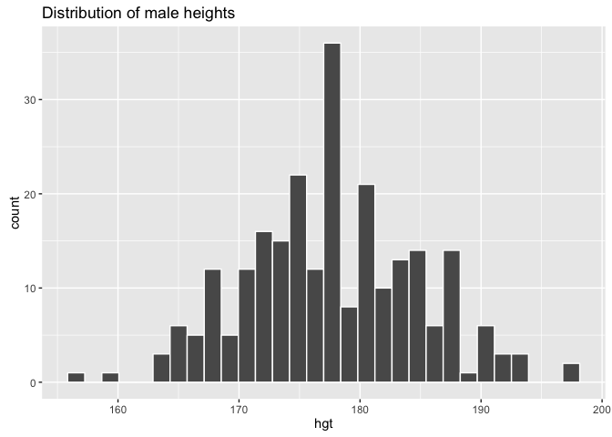

```r
qplot(x = hgt, data = mdims, geom = "histogram", col = I("white"), main = "Distribution of male heights")
```

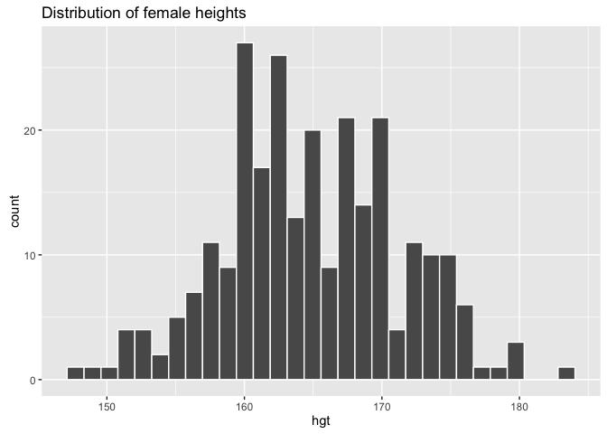

```r
qplot(x = hgt, data = fdims, geom = "histogram", col = I("white"), main = "Distribution of female heights")
```

*The shape of the two distributions are quite similar: both male and female heights show a symmetric and unimodal distribution (the multiple modes here are best thought of as a result of sampling variability and a small binwidth). The spread of the two distributions is also similar, with most of the observations falling within an interval spanning ~25 cm. They differ most notably in their centers, with a mean/median/mode of ~178 cm and ~165 cm for men and women, respectively.*

```r
sim_norm <- rnorm(n = length(fdims$hgt), mean = fhgtmean, sd = fhgtsd)
```

3. Make a normal probability plot of `sim_norm`. Do all of the points fall on the line? How does this plot compare to the probability plot for the real data?

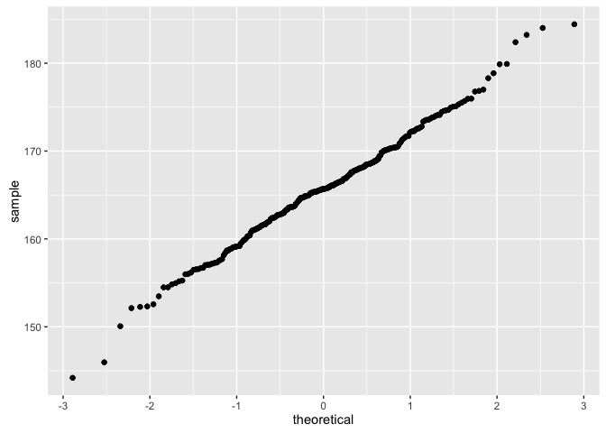

```r
qplot(sample = sim_norm) + stat_qq()
```

*The points don’t fall exactly on a line, but they’re quite close. The largest deviations come in the tail of the distribution. This simulated plot is more smoothly linear than the data, but that is likely due to a discretization in the data*.

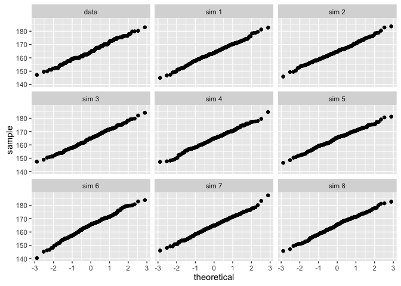

```r
qqnormsim(sample = hgt, data = fdims)
```

4. Does the normal probability plot for female heights look similar to the plots created for the simulated data? That is, do plots provide evidence that the female heights are nearly normal?

*The Q-Q plot for female heights is strikingly similar to that from simulated normal data sets. In fact, several of the simulated plots show a greater deviation from linearity in the tails that does the original data. Again, the main difference is that the data has a stair-step shape.*

5. Using the same technique, determine whether or not female weights appear to come from a normal distribution.

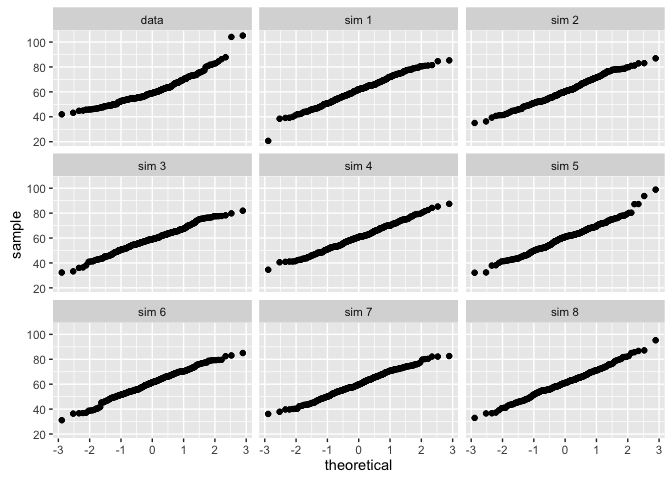

```r
qqnormsim(sample = wgt, data = fdims)
```

*The normal approximation appears to be less appropriate for `wgt` than for `hgt`. This data shows some curvature in the shape of the qqplot that suggests a longer right tail that we’d expect from nearly normal data and also shows two notable outliers.*

6. Write out two probability questions that you would like to answer; one regarding female heights and one regarding female weights. Calculate the those probabilities using both the theoretical normal distribution as well as the empirical distribution (four probabilities in all). Which variable, height or weight, had a closer agreement between the two methods?

*Answers will vary here. The important thing is to use `pnorm` to find the area under the curve to the Left of a value and use `sum(data meeting condition) / length(data)` to find the empirical probabilities.*

## On Your Own

- Now let’s consider some of the other variables in the body dimensions data set. Using the figures at the end of the exercises, match the histogram to its normal probability plot. All of the variables have been standardized (first subtract the mean, then divide by the standard deviation), so the units won’t be of any help. If you are uncertain based on these figures, generate the plots in R to check.

  **a.** The histogram for female biiliac (pelvic) diameter (`bii.di`) belongs to normal probability plot letter B.

  **b.** The histogram for female elbow diameter (`elb.di`) belongs to normal probability plot letter C.

  **c.** The histogram for general age (`age`) belongs to normal probability plot letter D.

  **d.** The histogram for female chest depth (`che.de`) belongs to normal probability plot letter A.
- Note that normal probability plots C and D have a slight stepwise pattern.  
  Why do you think this is the case?

*This is likely due to the discrete scale on which the data was measured. When people report their age, they usually only provide integer values, not ages like 28.3746 years. This is what creates the step pattern in the variable on the y-axis of the qqplot. The x-axis refers to the percentiles of the normal distribution, which is continuous, so the plots are continuous in their x-values.*

- As you can see, normal probability plots can be used both to assess normality and visualize skewness. Make a normal probability plot for female knee diameter (`kne.di`). Based on this normal probability plot, is this variable left skewed, symmetric, or right skewed? Use a histogram to confirm your findings.

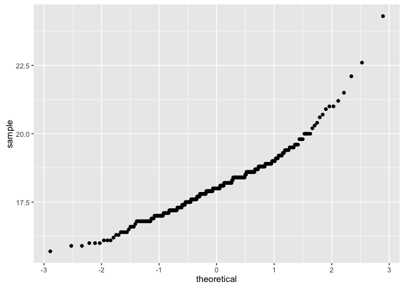

```r
qplot(sample = kne.di, data = fdims, stat = "qq")
```

*It is very clear that the normal curve would be a poor approximation to female knee diameter. The Q-Q plot shows strong deviations from linearity in the right tail, suggesting that it’s longer (right-skewed) than we’d expect under the normal distribution. We can verify this by looking at the histogram.*

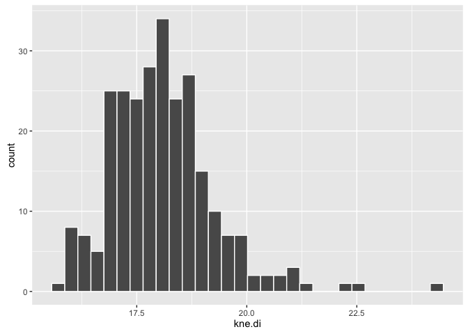

[figure not shown]

```r
qplot(x = kne.di, data = fdims, col = I("white"), geom = "histogram")
```

This is a product of OpenIntro that is released under a [Creative Commons Attribution-ShareAlike 3.0 Unported](http://creativecommons.org/licenses/by-sa/3.0). This lab was adapted for OpenIntro by Andrew Bray, Chester Ismay, and Mine Çetinkaya-Rundel from a lab written by Mark Hansen of UCLA Statistics.